# NOAA Storm Database Data Analysis

Antonio Marquez Palacios

November 11, 2017

## Synopsis

Storms and other severe weather events can cause both public health and economic problems for communities and municipalities. Many severe events can result in fatalities, injuries, and property damage, and preventing such outcomes to the extent possible is a key concern.

As part of Data Science Specialization’s Reproducible Research Project 2 Assignment, this project will explore the U.S. NOAA’s storm database. This database tracks characteristics of major storms and weather events in the United States, including when and where they occur, as well as estimates of any fatalities, injuries, and property damage.

## Data Processing

NOAA’s Storm database is available at the following URL location:

https://d396qusza40orc.cloudfront.net/repdata%2Fdata%2FStormData.csv.bz2

For information about how data is collected and description about the variables, please refer to https://d396qusza40orc.cloudfront.net/repdata%2Fpeer2_doc%2Fpd01016005curr.pdf

### Load the data:

The data is compressed in a bz2 file, but can be read directly from it using the read.csv function. This will take some time to load:

```r
FILENAME      <- "repdata%2Fdata%2FStormData.csv.bz2"
NOAAS_DT      <- read.csv(FILENAME, header = TRUE, sep = ",",  quote = "\"")
```

Once loaded, an initial analysis at how it looks like will help to determine if data transformations are required, so let’s do a summary first:

```r
summary(NOAAS_DT)
```

```
##     STATE__                  BGN_DATE             BGN_TIME
##  Min.   : 1.0   5/25/2011 0:00:00:  1202   12:00:00 AM: 10163
##  1st Qu.:19.0   4/27/2011 0:00:00:  1193   06:00:00 PM:  7350
##  Median :30.0   6/9/2011 0:00:00 :  1030   04:00:00 PM:  7261
##  Mean   :31.2   5/30/2004 0:00:00:  1016   05:00:00 PM:  6891
##  3rd Qu.:45.0   4/4/2011 0:00:00 :  1009   12:00:00 PM:  6703
##  Max.   :95.0   4/2/2006 0:00:00 :   981   03:00:00 PM:  6700
##                 (Other)          :895866   (Other)    :857229
##    TIME_ZONE          COUNTY           COUNTYNAME         STATE
##  CST    :547493   Min.   :  0.0   JEFFERSON :  7840   TX     : 83728
##  EST    :245558   1st Qu.: 31.0   WASHINGTON:  7603   KS     : 53440
##  MST    : 68390   Median : 75.0   JACKSON   :  6660   OK     : 46802
##  PST    : 28302   Mean   :100.6   FRANKLIN  :  6256   MO     : 35648
##  AST    :  6360   3rd Qu.:131.0   LINCOLN   :  5937   IA     : 31069
##  HST    :  2563   Max.   :873.0   MADISON   :  5632   NE     : 30271
##  (Other):  3631                   (Other)   :862369   (Other):621339
##                EVTYPE         BGN_RANGE           BGN_AZI
##  HAIL             :288661   Min.   :   0.000          :547332
##  TSTM WIND        :219940   1st Qu.:   0.000   N      : 86752
##  THUNDERSTORM WIND: 82563   Median :   0.000   W      : 38446
##  TORNADO          : 60652   Mean   :   1.484   S      : 37558
##  FLASH FLOOD      : 54277   3rd Qu.:   1.000   E      : 33178
##  FLOOD            : 25326   Max.   :3749.000   NW     : 24041
##  (Other)          :170878                      (Other):134990
##          BGN_LOCATI                  END_DATE             END_TIME
##               :287743                    :243411              :238978
##  COUNTYWIDE   : 19680   4/27/2011 0:00:00:  1214   06:00:00 PM:  9802
##  Countywide   :   993   5/25/2011 0:00:00:  1196   05:00:00 PM:  8314
##  SPRINGFIELD  :   843   6/9/2011 0:00:00 :  1021   04:00:00 PM:  8104
##  SOUTH PORTION:   810   4/4/2011 0:00:00 :  1007   12:00:00 PM:  7483
##  NORTH PORTION:   784   5/30/2004 0:00:00:   998   11:59:00 PM:  7184
##  (Other)      :591444   (Other)          :653450   (Other)    :622432
##    COUNTY_END COUNTYENDN       END_RANGE           END_AZI
##  Min.   :0    Mode:logical   Min.   :  0.0000          :724837
##  1st Qu.:0    NA's:902297    1st Qu.:  0.0000   N      : 28082
##  Median :0                   Median :  0.0000   S      : 22510
##  Mean   :0                   Mean   :  0.9862   W      : 20119
##  3rd Qu.:0                   3rd Qu.:  0.0000   E      : 20047
##  Max.   :0                   Max.   :925.0000   NE     : 14606
##                                                 (Other): 72096
```

[output cut: 41 more lines]

```
##  Min.   :   0   Min.   :-14451   Min.   :   0   Min.   :-14455
##  1st Qu.:2802   1st Qu.:  7247   1st Qu.:   0   1st Qu.:     0
##  Median :3540   Median :  8707   Median :   0   Median :     0
##  Mean   :2875   Mean   :  6940   Mean   :1452   Mean   :  3509
##  3rd Qu.:4019   3rd Qu.:  9605   3rd Qu.:3549   3rd Qu.:  8735
##  Max.   :9706   Max.   : 17124   Max.   :9706   Max.   :106220
##  NA's   :47                      NA's   :40
##                                            REMARKS           REFNUM
##                                                :287433   Min.   :     1
##                                                : 24013   1st Qu.:225575
##  Trees down.\n                                 :  1110   Median :451149
##  Several trees were blown down.\n              :   568   Mean   :451149
##  Trees were downed.\n                          :   446   3rd Qu.:676723
##  Large trees and power lines were blown down.\n:   432   Max.   :902297
##  (Other)                                       :588295
```

Very verbose output is quite complicated to distinguish for any special processing on the data so try looking at the structure of the dataset:

```r
str(NOAAS_DT)
```

```
## 'data.frame':    902297 obs. of  37 variables:
##  $ STATE__   : num  1 1 1 1 1 1 1 1 1 1 ...
##  $ BGN_DATE  : Factor w/ 16335 levels "1/1/1966 0:00:00",..: 6523 6523 4242 11116 2224 2224 2260 383 3980 3980 ...
##  $ BGN_TIME  : Factor w/ 3608 levels "00:00:00 AM",..: 272 287 2705 1683 2584 3186 242 1683 3186 3186 ...
##  $ TIME_ZONE : Factor w/ 22 levels "ADT","AKS","AST",..: 7 7 7 7 7 7 7 7 7 7 ...
##  $ COUNTY    : num  97 3 57 89 43 77 9 123 125 57 ...
##  $ COUNTYNAME: Factor w/ 29601 levels "","5NM E OF MACKINAC BRIDGE TO PRESQUE ISLE LT MI",..: 13513 1873 4598 10592 4372 10094 1973 23873 24418 4598 ...
##  $ STATE     : Factor w/ 72 levels "AK","AL","AM",..: 2 2 2 2 2 2 2 2 2 2 ...
##  $ EVTYPE    : Factor w/ 985 levels "   HIGH SURF ADVISORY",..: 834 834 834 834 834 834 834 834 834 834 ...
##  $ BGN_RANGE : num  0 0 0 0 0 0 0 0 0 0 ...
##  $ BGN_AZI   : Factor w/ 35 levels "","  N"," NW",..: 1 1 1 1 1 1 1 1 1 1 ...
##  $ BGN_LOCATI: Factor w/ 54429 levels "","- 1 N Albion",..: 1 1 1 1 1 1 1 1 1 1 ...
##  $ END_DATE  : Factor w/ 6663 levels "","1/1/1993 0:00:00",..: 1 1 1 1 1 1 1 1 1 1 ...
##  $ END_TIME  : Factor w/ 3647 levels ""," 0900CST",..: 1 1 1 1 1 1 1 1 1 1 ...
##  $ COUNTY_END: num  0 0 0 0 0 0 0 0 0 0 ...
```

[output cut: 23 more lines]

From the output abotve it can be seen that no special transformations are required to prepare data, so continue with the analysis.

This analysis is focused to answer the following questions:

1. Across the United States, which types of events (as indicated in the EVTYPE variable) are most harmful with respect to population health?
2. Across the United States, which types of events have the greatest economic consequences?

The following sections will cover details about the data analysis required find the answers

### 1. Across the United States, which types of events (as indicated in the EVTYPE variable) are most harmful with respect to population health?

Consider population-health harm events those which end with fatalities or injuries, so in order to answer this question, it is required to calculate the total number of fatalities and injuries per event.

Lets sum the fatalities and injuries in a new column called total_victims:

```r
library(dplyr)
```

```r
library(grDevices)
library(ggplot2)

NOAAS_DT$TOTAL_VICTIMS <- NOAAS_DT$FATALITIES + NOAAS_DT$INJURIES
```

Now, it is required to group by event the total number of victims, so that way it can be seen which event is the most harmful. To achieve this, the use of the group_by dyplr’s function pipelined with summarise will do the work. After that let’s show the 10 most harmful events

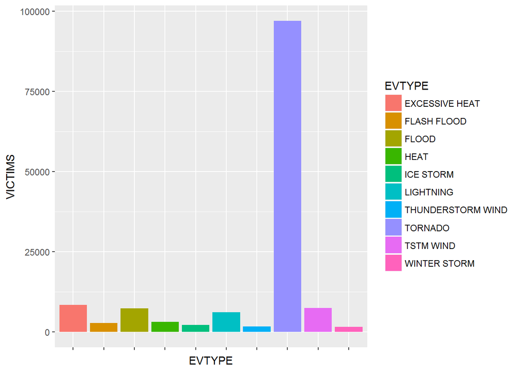

```r
# The trick is done by grouping by Event Type and do a summary counting the number of victims
noaas_evtype_victims <- NOAAS_DT %>% group_by(EVTYPE) %>% summarise(VICTIMS = sum(TOTAL_VICTIMS)) %>% arrange(desc(VICTIMS))

#get the top ten most harmful events
noaas_evtype_victims <- noaas_evtype_victims[1:10, ]

ggplot(noaas_evtype_victims, aes(x=EVTYPE, y=VICTIMS)) + geom_bar(stat="identity", aes(fill=EVTYPE)) + scale_x_discrete(labels=c())
```

The plot above clearly shows that Tornados lead more victims with a huge difference to other events

### 2. Across the United States, which types of events have the greatest economic consequences?

Additionally, NOAAS Dataset does specify damages magnitude using an acronym: h: 100 factor K: 1000 factor M: 1000000 factor B: 1000000000 factor

NOAAS Dataset PROPDMGEXP and NOAAS Dataset CROPDMGEXP specify the magnitude for each observation accordingly.

Again, grouping is the key task to present the data for the given question. The following code spippet does the work:

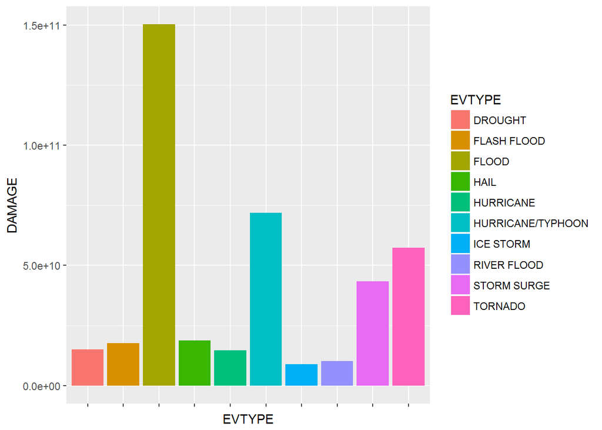

```r
#define the factors:
H_FACTOR <- 100
K_FACTOR <- 1000
M_FACTOR <- K_FACTOR * K_FACTOR
B_FACTOR <- M_FACTOR * K_FACTOR

NOAAS_DT$PROPDMG[NOAAS_DT$PROPDMGEXP == ""] <- NOAAS_DT$PROPDMG[NOAAS_DT$PROPDMGEXP == ""] * 1
NOAAS_DT$PROPDMG[NOAAS_DT$PROPDMGEXP == "0"] <- NOAAS_DT$PROPDMG[NOAAS_DT$PROPDMGEXP == "0"] * 1
NOAAS_DT$PROPDMG[NOAAS_DT$PROPDMGEXP == "1"] <- NOAAS_DT$PROPDMG[NOAAS_DT$PROPDMGEXP == "1"] * 1
NOAAS_DT$PROPDMG[NOAAS_DT$PROPDMGEXP == "2"] <- NOAAS_DT$PROPDMG[NOAAS_DT$PROPDMGEXP == "2"] * 1
NOAAS_DT$PROPDMG[NOAAS_DT$PROPDMGEXP == "3"] <- NOAAS_DT$PROPDMG[NOAAS_DT$PROPDMGEXP == "3"] * 1
NOAAS_DT$PROPDMG[NOAAS_DT$PROPDMGEXP == "4"] <- NOAAS_DT$PROPDMG[NOAAS_DT$PROPDMGEXP == "4"] * 1
NOAAS_DT$PROPDMG[NOAAS_DT$PROPDMGEXP == "5"] <- NOAAS_DT$PROPDMG[NOAAS_DT$PROPDMGEXP == "5"] * 1
NOAAS_DT$PROPDMG[NOAAS_DT$PROPDMGEXP == "6"] <- NOAAS_DT$PROPDMG[NOAAS_DT$PROPDMGEXP == "6"] * 1
NOAAS_DT$PROPDMG[NOAAS_DT$PROPDMGEXP == "7"] <- NOAAS_DT$PROPDMG[NOAAS_DT$PROPDMGEXP == "7"] * 1
NOAAS_DT$PROPDMG[NOAAS_DT$PROPDMGEXP == "8"] <- NOAAS_DT$PROPDMG[NOAAS_DT$PROPDMGEXP == "8"] * 1
NOAAS_DT$PROPDMG[NOAAS_DT$PROPDMGEXP == "+"] <- NOAAS_DT$PROPDMG[NOAAS_DT$PROPDMGEXP == "+"] * 1
NOAAS_DT$PROPDMG[NOAAS_DT$PROPDMGEXP == "8"] <- NOAAS_DT$PROPDMG[NOAAS_DT$PROPDMGEXP == "-"] * 1
NOAAS_DT$PROPDMG[NOAAS_DT$PROPDMGEXP == "K"] <- NOAAS_DT$PROPDMG[NOAAS_DT$PROPDMGEXP == "K"] * K_FACTOR
NOAAS_DT$PROPDMG[NOAAS_DT$PROPDMGEXP == "M"] <- NOAAS_DT$PROPDMG[NOAAS_DT$PROPDMGEXP == "M"] * M_FACTOR
NOAAS_DT$PROPDMG[NOAAS_DT$PROPDMGEXP == "B"] <- NOAAS_DT$PROPDMG[NOAAS_DT$PROPDMGEXP == "B"] * B_FACTOR
NOAAS_DT$PROPDMG[NOAAS_DT$PROPDMGEXP == "h"] <- NOAAS_DT$PROPDMG[NOAAS_DT$PROPDMGEXP == "h"] * H_FACTOR


NOAAS_DT$CROPDMG[NOAAS_DT$CROPDMGEXP == ""] <- NOAAS_DT$CROPDMG[NOAAS_DT$CROPDMGEXP == ""] * 1
NOAAS_DT$CROPDMG[NOAAS_DT$CROPDMGEXP == "0"] <- NOAAS_DT$CROPDMG[NOAAS_DT$CROPDMGEXP == "0"] * 1
NOAAS_DT$CROPDMG[NOAAS_DT$CROPDMGEXP == "2"] <- NOAAS_DT$CROPDMG[NOAAS_DT$CROPDMGEXP == "2"] * 1
NOAAS_DT$CROPDMG[NOAAS_DT$CROPDMGEXP == "?"] <- NOAAS_DT$CROPDMG[NOAAS_DT$CROPDMGEXP == "?"] * 1
NOAAS_DT$CROPDMG[NOAAS_DT$CROPDMGEXP == "B"] <- NOAAS_DT$CROPDMG[NOAAS_DT$CROPDMGEXP == "B"] * B_FACTOR
NOAAS_DT$CROPDMG[NOAAS_DT$CROPDMGEXP == "K"] <- NOAAS_DT$CROPDMG[NOAAS_DT$CROPDMGEXP == "K"] * K_FACTOR
NOAAS_DT$CROPDMG[NOAAS_DT$CROPDMGEXP == "M"] <- NOAAS_DT$CROPDMG[NOAAS_DT$CROPDMGEXP == "M"] * M_FACTOR

# grouping will do the magic
noaas_evtype_dmg <- NOAAS_DT %>% group_by(EVTYPE) %>% summarise(DAMAGE = sum(PROPDMG+CROPDMG)) %>% arrange(desc(DAMAGE))

noaas_evtype_dmg <- noaas_evtype_dmg[1:10, ]

ggplot(noaas_evtype_dmg, aes(x=EVTYPE, y=DAMAGE)) + geom_bar(stat="identity", aes(fill=EVTYPE)) + scale_x_discrete(labels=c())
```

The 10 most hamlful events, regarding economic consequences, are shown in the graph above.

## Results

1. Based on the analysis Tornados are the most harmful events for population health in the U.S.
2. Floods, followed by hurricane/typhoon causes the most economic negative consequences in the U.S.